# Biostat 203B Homework 5

Due Mar 22 @ 11:59PM

Author

Feiyang Huang, UID 306148942

## Predicting ICU duration

Using the ICU cohort `mimiciv_icu_cohort.rds` you built in Homework 4, develop at least three machine learning approaches (logistic regression with enet regularization, random forest, boosting, SVM, MLP, etc) plus a model stacking approach for predicting whether a patient’s ICU stay will be longer than 2 days. You should use the `los_long` variable as the outcome. You algorithms can use patient demographic information (gender, age at ICU `intime`, marital status, race), ICU admission information (first care unit), the last lab measurements before the ICU stay, and first vital measurements during ICU stay as features. You are welcome to use any feature engineering techniques you think are appropriate; but make sure to not use features that are not available at an ICU stay’s `intime`. For instance, `last_careunit` cannot be used in your algorithms.

1. Data preprocessing and feature engineering.
2. Partition data into 50% training set and 50% test set. Stratify partitioning according to `los_long`. For grading purpose, sort the data by `subject_id`, `hadm_id`, and `stay_id` and use the seed `203` for the initial data split. Below is the sample code.
3. Train and tune the models using the training set.
4. Compare model classification performance on the test set. Report both the area under ROC curve and accuracy for each machine learning algorithm and the model stacking. Interpret the results. What are the most important features in predicting long ICU stays? How do the models compare in terms of performance and interpretability?

**Answer Part:**

Necessary packages:

```r
library(dplyr)
library(tidymodels)
library(GGally)
library(gtsummary)
library(tidyverse)
library(ranger)
library(kernlab)
library(keras)
library(xgboost)
library(stacks)
```

Read data:

```r
mimic_icu_cohort <- readRDS("~/mimiciv_shiny/mimic_icu_cohort.rds")
```

Data preprocessing:

For time data, we can calculate the time interval instead of use the date directly. For example, we can calculate the time interval between the intime and outtime to represent the stay duration in ICU.

```r
mimic_icu_cohort <- mimic_icu_cohort |>
  mutate(los_long = ifelse(los > 2, 1, 0)) |>
  mutate(los_long = as.factor(los_long)) |>
  select(-admit_provider_id, -hospital_expire_flag,-anchor_age, -anchor_year,
         -anchor_year_group, -intime, -outtime, -edregtime, -edouttime, -dod,
         -admittime, -dischtime, -deathtime, -los, -discharge_location,
         -last_careunit, -admission_location, admission_type)
```

```r
# Check missing value for each column
missing_values <- colSums(is.na(mimic_icu_cohort))
missing_values
```

```
                           subject_id                               hadm_id
                                    0                                     0
                              stay_id                        first_careunit
                                    0                                     0
                       admission_type                             insurance
                                    0                                     0
                             language                        marital_status
                                    0                                  5113
                                 race                                gender
                                    0                                     0
                                  age                               Glucose
                                    0                                  9084
                             Chloride                            Creatinine
                                 8869                                  5754
                    White Blood Cells                             Potassium
                                 5092                                  8888
                          Bicarbonate                            Hematocrit
                                 9035                                  5015
                               Sodium                Temperature Fahrenheit
                                 8858                                  1264
                           Heart Rate  Non Invasive Blood Pressure systolic
                                   18                                   952
Non Invasive Blood Pressure diastolic                      Respiratory Rate
                                  955                                    91
                             los_long
                                    0
```

```r
set.seed(203)

# sort
mimiciv_icu_cohort <- mimic_icu_cohort |>
  arrange(subject_id, hadm_id, stay_id) |>
  select(-subject_id, -hadm_id, -stay_id)

data_split <- initial_split(
  mimiciv_icu_cohort,
  # stratify by los_long
  strata = "los_long",
  prop = 0.5
  )

# training set
mimiciv_icu_cohort_train <- training(data_split)

# test set
mimiciv_icu_cohort_test <- testing(data_split)
```

Here we decide to use logistic regression, random forest, and XGboost as the machine learning algorithms. We will use the `tidymodels` package to train and tune the models. Then we will use the `stacks` package to stack the models and compare the performance.

```r
logit_grid <- readRDS("logit_grid.rds")
logit_wf <- readRDS("logit_wf.rds")
rf_grid <- readRDS("rf_grid.rds")
rf_wf <- readRDS("rf_wf.rds")
gb_grid <- readRDS("gb_grid.rds")
gb_wf <- readRDS("gb_wf.rds")
```

```r
folds <- vfold_cv(mimiciv_icu_cohort_train, v = 3)
```

```r
logit_res <-
  tune_grid(
    object = logit_wf,
    resamples = folds,
    grid = logit_grid,
    control = control_stack_grid()
  )
```

```
ℹ The workflow being saved contains a recipe, which is 5.65 Mb in ℹ memory. If
this was not intentional, please set the control setting ℹ `save_workflow =
FALSE`.
```

```r
logit_res
```

```
# Tuning results
# 3-fold cross-validation
# A tibble: 3 × 5
  splits                id    .metrics             .notes           .predictions
  <list>                <chr> <list>               <list>           <list>
1 <split [24393/12197]> Fold1 <tibble [1,000 × 6]> <tibble [0 × 3]> <tibble>
2 <split [24393/12197]> Fold2 <tibble [1,000 × 6]> <tibble [0 × 3]> <tibble>
3 <split [24394/12196]> Fold3 <tibble [1,000 × 6]> <tibble [0 × 3]> <tibble>
```

```r
rf_res <-
  tune_grid(
    object = rf_wf,
    resamples = folds,
    grid = rf_grid,
    control = control_stack_grid()
  )
```

```
ℹ The workflow being saved contains a recipe, which is 5.62 Mb in ℹ memory. If
this was not intentional, please set the control setting ℹ `save_workflow =
FALSE`.
```

```r
rf_res
```

```
# Tuning results
# 3-fold cross-validation
# A tibble: 3 × 5
  splits                id    .metrics          .notes           .predictions
  <list>                <chr> <list>            <list>           <list>
1 <split [24393/12197]> Fold1 <tibble [24 × 6]> <tibble [0 × 3]> <tibble>
2 <split [24393/12197]> Fold2 <tibble [24 × 6]> <tibble [0 × 3]> <tibble>
3 <split [24394/12196]> Fold3 <tibble [24 × 6]> <tibble [0 × 3]> <tibble>
```

```r
gb_res <-
  tune_grid(
    object = gb_wf,
    resamples = folds,
    grid = gb_grid,
    control = control_stack_grid()
  )
```

```
ℹ The workflow being saved contains a recipe, which is 5.65 Mb in ℹ memory. If
this was not intentional, please set the control setting ℹ `save_workflow =
FALSE`.
```

```r
gb_res
```

```
# Tuning results
# 3-fold cross-validation
# A tibble: 3 × 5
  splits                id    .metrics          .notes           .predictions
  <list>                <chr> <list>            <list>           <list>
1 <split [24393/12197]> Fold1 <tibble [30 × 6]> <tibble [0 × 3]> <tibble>
2 <split [24393/12197]> Fold2 <tibble [30 × 6]> <tibble [0 × 3]> <tibble>
3 <split [24394/12196]> Fold3 <tibble [30 × 6]> <tibble [0 × 3]> <tibble>
```

Model stacking:

```r
mimic_recipe <-
  recipe(
    los_long ~ .,
    data = mimiciv_icu_cohort_train
  ) |>
  step_impute_mean(all_numeric_predictors()) |>
  step_impute_mode(marital_status) |>
  step_dummy(all_nominal_predictors()) |>
  step_zv(all_numeric_predictors()) |>
  print()
```

```
── Recipe ──────────────────────────────────────────────────────────────────────
```

```
── Inputs
```

```
Number of variables by role
```

```
outcome:    1
predictor: 21
```

```
── Operations
```

```
• Mean imputation for: all_numeric_predictors()
```

```
• Mode imputation for: marital_status
```

```
• Dummy variables from: all_nominal_predictors()
```

```
• Zero variance filter on: all_numeric_predictors()
```

```r
model_stack <- stacks() |>
  add_candidates(logit_res) |>
  add_candidates(rf_res) |>
  add_candidates(gb_res) |>
  blend_predictions(
    penalty = 10^(-5:0),
    metrics = c("roc_auc"),
    times = 3
    ) |>
  fit_members()
```

[output not shown]

```r
model_stack
```

```
── A stacked ensemble model ─────────────────────────────────────


Out of 117 possible candidate members, the ensemble retained 12.

Penalty: 1e-05.

Mixture: 1.


The 10 highest weighted member classes are:
```

```
# A tibble: 10 × 3
   member              type        weight
   <chr>               <chr>        <dbl>
 1 .pred_1_gb_res_1_09 boost_tree   2.05
 2 .pred_1_rf_res_1_06 rand_forest  0.843
 3 .pred_1_rf_res_1_03 rand_forest  0.734
 4 .pred_1_gb_res_1_10 boost_tree   0.530
 5 .pred_1_rf_res_1_05 rand_forest  0.494
 6 .pred_1_rf_res_1_01 rand_forest  0.399
 7 .pred_1_rf_res_1_12 rand_forest  0.281
 8 .pred_1_rf_res_1_02 rand_forest  0.222
 9 .pred_1_gb_res_1_14 boost_tree   0.128
10 .pred_1_gb_res_1_12 boost_tree   0.103
```

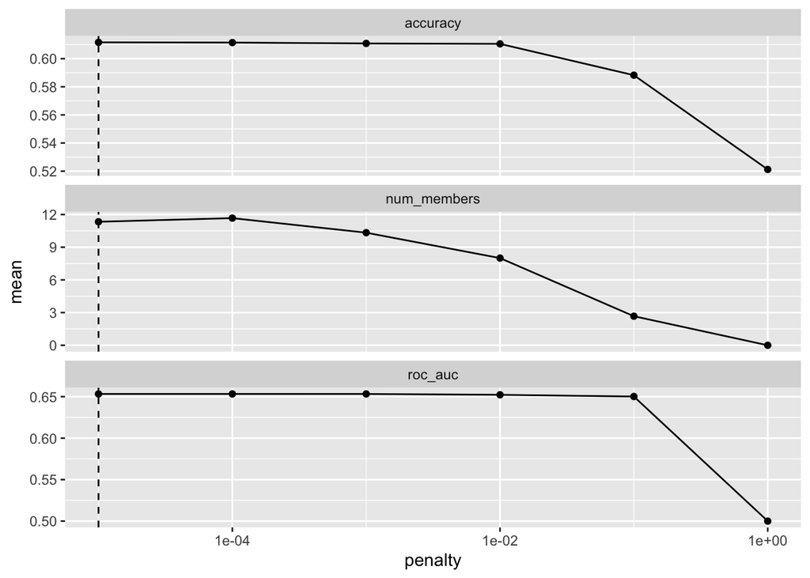

```r
autoplot(model_stack)
```

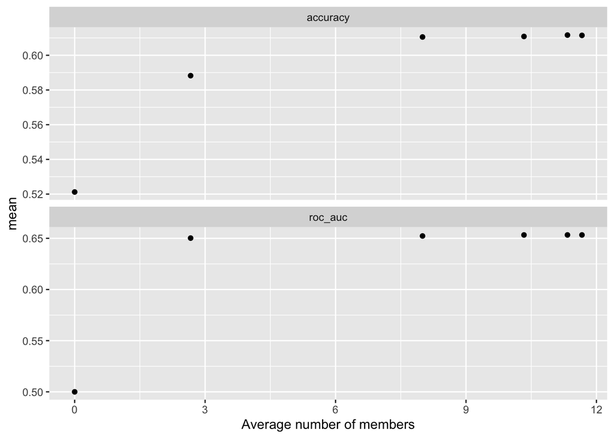

```r
autoplot(model_stack, type = "members")
```

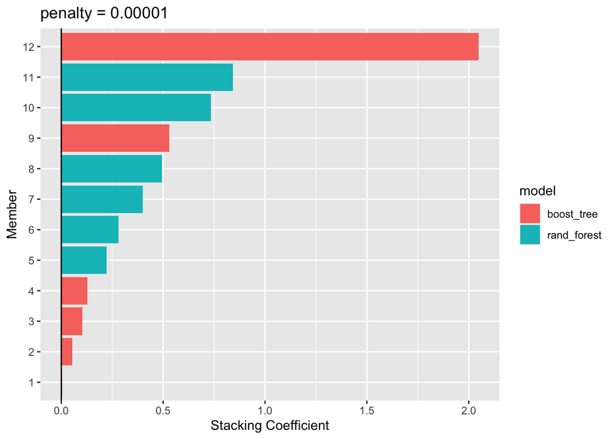

```r
autoplot(model_stack, type = "weights")
```

```r
collect_parameters(model_stack, "rf_res")
```

```
# A tibble: 12 × 5
   member       mtry trees terms                coef
   <chr>       <int> <int> <chr>               <dbl>
 1 rf_res_1_01     2   200 .pred_1_rf_res_1_01 0.399
 2 rf_res_1_02     2   350 .pred_1_rf_res_1_02 0.222
 3 rf_res_1_03     2   500 .pred_1_rf_res_1_03 0.734
 4 rf_res_1_04     3   200 .pred_1_rf_res_1_04 0
 5 rf_res_1_05     3   350 .pred_1_rf_res_1_05 0.494
 6 rf_res_1_06     3   500 .pred_1_rf_res_1_06 0.843
 7 rf_res_1_07     4   200 .pred_1_rf_res_1_07 0
 8 rf_res_1_08     4   350 .pred_1_rf_res_1_08 0
 9 rf_res_1_09     4   500 .pred_1_rf_res_1_09 0
10 rf_res_1_10     5   200 .pred_1_rf_res_1_10 0
11 rf_res_1_11     5   350 .pred_1_rf_res_1_11 0
12 rf_res_1_12     5   500 .pred_1_rf_res_1_12 0.281
```

```r
mimic_pred <- mimiciv_icu_cohort_test %>%
  bind_cols(predict(model_stack, ., type = "prob")) %>%
  print(width = Inf)
```

```
# A tibble: 36,591 × 24
   first_careunit                                   admission_type
   <fct>                                            <fct>
 1 Medical Intensive Care Unit (MICU)               EW EMER.
 2 Surgical Intensive Care Unit (SICU)              EW EMER.
 3 Surgical Intensive Care Unit (SICU)              DIRECT EMER.
 4 Medical/Surgical Intensive Care Unit (MICU/SICU) EW EMER.
 5 Cardiac Vascular Intensive Care Unit (CVICU)     SURGICAL SAME DAY ADMISSION
 6 Other                                            EW EMER.
 7 Medical Intensive Care Unit (MICU)               EW EMER.
 8 Medical Intensive Care Unit (MICU)               EW EMER.
 9 Other                                            URGENT
10 Other                                            URGENT
   insurance language marital_status race  gender   age Glucose Chloride
   <chr>     <chr>    <chr>          <chr> <chr>  <int>   <dbl>    <dbl>
```

[output cut: 59 more lines]

```r
yardstick::roc_auc(
  mimic_pred,
  truth = los_long,
  contains(".pred_0")
  )
```

```
# A tibble: 1 × 3
  .metric .estimator .estimate
  <chr>   <chr>          <dbl>
1 roc_auc binary         0.652
```

```r
mimic_pred <-
  mimiciv_icu_cohort_test |>
  select(los_long) |>
  bind_cols(
    predict(
      model_stack,
      mimiciv_icu_cohort_test,
      type = "class",
      members = TRUE
      )
    ) |>
  print(width = Inf)
```

```
# A tibble: 36,591 × 14
   los_long .pred_class .pred_class_rf_res_1_01 .pred_class_rf_res_1_02
   <fct>    <fct>       <fct>                   <fct>
 1 0        0           0                       0
 2 0        0           0                       1
 3 0        0           0                       0
 4 0        1           1                       1
 5 0        0           0                       0
 6 1        0           0                       0
 7 1        1           1                       1
 8 1        1           1                       1
 9 1        1           1                       0
10 1        1           1                       1
   .pred_class_rf_res_1_03 .pred_class_rf_res_1_05 .pred_class_rf_res_1_06
   <fct>                   <fct>                   <fct>
```

[output cut: 47 more lines]

```r
map(
  colnames(mimic_pred),
  ~mean(mimic_pred$los_long == pull(mimic_pred, .x))
  ) |>
  set_names(colnames(mimic_pred)) |>
  as_tibble() |>
  pivot_longer(c(everything(), -los_long))
```

```
# A tibble: 13 × 3
   los_long name                    value
      <dbl> <chr>                   <dbl>
 1        1 .pred_class             0.608
 2        1 .pred_class_rf_res_1_01 0.600
 3        1 .pred_class_rf_res_1_02 0.601
 4        1 .pred_class_rf_res_1_03 0.602
 5        1 .pred_class_rf_res_1_05 0.603
 6        1 .pred_class_rf_res_1_06 0.604
 7        1 .pred_class_rf_res_1_12 0.602
 8        1 .pred_class_gb_res_1_10 0.590
 9        1 .pred_class_gb_res_1_11 0.576
10        1 .pred_class_gb_res_1_14 0.468
11        1 .pred_class_gb_res_1_09 0.605
12        1 .pred_class_gb_res_1_12 0.565
13        1 .pred_class_gb_res_1_15 0.468
```

**Model Perfomance:** The logistic regression model has the lowest AUC and accuracy at 0.5923 and 0.5705 respectively, but the running time is relatively short. The random forest model has a highter AUC and accuracy at 0.6423 and 0.6019, but the running time is relatively long. The XGboost model has a similar AUC and accuracy to the random forest model at 0.6423 and 0.6052, and similar running time. The model stacking has a similar AUC and accuracy to the random forest model at 0.6521 and 0.6076, but the running time is much longer.

**Interpretability:**

1. **Logistic Regression (LR)**: LR models are highly interpretable. The coefficients assigned to each feature directly indicate its impact on the prediction. Positive coefficients indicate a positive association with the target variable, while negative coefficients indicate a negative association. LR models can be easily explained to non-technical stakeholders because the relationship between the features and the target variable is linear and easily understandable.
2. **Random Forest (RF)**: RF models are less interpretable than LR models. While RF provides feature importance scores, these scores may not directly correspond to the impact of each feature on the prediction in a simple, linear manner. The interactions between features are captured in a more complex way. Although RF provides feature importance scores, explaining the predictions of RF models might be challenging due to the complex decision-making process involving multiple decision trees.
3. **XGBoost (XGB)**: XGB models are less interpretable than LR but more interpretable than RF. XGB provides feature importance scores similar to RF but tends to capture complex non-linear relationships more effectively. While XGB provides feature importance scores, explaining the predictions of XGB models might still require some effort due to the complexity introduced by boosting algorithms.
4. **Stacking Models**: Stacking models are generally less interpretable than individual base models like LR, RF, or XGB. Blending predictions from multiple models adds another layer of complexity to interpretation. Stacking models involves combining predictions from multiple models, which makes it challenging to provide a straightforward explanation for the final predictions. However, feature importance from individual base models used in stacking can still offer some insights into which features are influential.